# R Notebook

```r
#ensuring all necessary libraries are set before running the code
library(tidyverse)
library(readxl)
library(tidyverse)
library(janitor)
library(ggplot2)
library(GGally)
library(rstatix)
```

## Data Wrangling

```r
#readxl commands necessary for multi-sheet excel document
data_file <- "BIOL3207_Assignment1_DataFile.xlsx"
read_xlsx(data_file, skip = 8)
```

| Range (square km) | Weight (kg) | Height (cm) | Species | Year |
| --- | --- | --- | --- | --- |
| 61.58645 | 19.1349958 | 64.31 | A fictus | 2011 |
| 64.15459 | 13.5973768 | 28.23 | A fictus | 2011 |
| 52.67555 | 11.3592042 | 63.09 | A mendacium | 2011 |
| 67.53988 | 12.9202561 | 54.59 | A fictus | 2011 |
| 55.84076 | 10.9434611 | 71.81 | A fictus | 2011 |
| 76.12899 | 6.7785345 | 66.90 | A mendacium | 2011 |
| 62.83124 | 17.1261238 | 64.32 | A fictus | 2011 |
| 62.92691 | 12.2805938 | 48.13 | A fictus | 2011 |
| 51.84806 | 9.0876971 | 90.63 | A fictus | 2011 |
| 56.13976 | 17.2166861 | 43.41 | A fictus | 2011 |

[output cut: 190 more lines]

```r
#creating the id names for the different sheets
site_names <- excel_sheets(data_file)
site_names
```

```
[1] "Field Site 1" "Field Site 2" "Field Site 3" "Field Site 4" "Field Site 5"
```

```r
#species names for easier coding in future
species_names <- c("A_fictus", "A_mendacium")
```

```r
#creating a list of data frames from each excel sheet
df_list <- map(set_names(excel_sheets(data_file)),
               read_excel, path = data_file)
#note the change in sheet names when converted to data frames
lapply(names(df_list), function(x)
       assign(x, df_list[[x]], envir = .GlobalEnv))
```

| This is data from a decade-long ecological study across five widely dispersed field sites. | ...2 | ...3 | ...4 | ...5 |
| --- | --- | --- | --- | --- |
| NA | NA | NA | NA | NA |
| Individuals from two species, A fictus and A mendacium, were observed and data was recorded on animal size (weight and height) and range. | NA | NA | NA | NA |
| NA | NA | NA | NA | NA |
| Each row represents the data for a single animal. | NA | NA | NA | NA |
| NA | NA | NA | NA | NA |
| Yes, some of these numbers are absurd! But, for the purposes of this exercise, they are real. | NA | NA | NA | NA |
| NA | NA | NA | NA | NA |
| Range (square km) | Weight (kg) | Height (cm) | Species | Year |
| 61.5864471640255 | 19.1349958174691 | 64.31 | A fictus | 2011 |
| 64.154590263497397 | 13.597376830668599 | 28.23 | A fictus | 2011 |

[output cut: 198 more lines]

| Range (square km) | Weight (kg) | Height (cm) | Species | Year |
| --- | --- | --- | --- | --- |
| 52.91015 | 18.052970 | 73.01 | A fictus | 2011 |
| 64.90711 | 24.578983 | 82.97 | A fictus | 2011 |
| 63.88274 | 20.721863 | 103.56 | A mendacium | 2011 |
| 70.70177 | 20.512001 | 78.97 | A mendacium | 2011 |
| 51.97522 | 18.171453 | 89.07 | A fictus | 2011 |
| 63.94108 | 22.093250 | 52.24 | A fictus | 2011 |
| 66.85582 | 23.777078 | 57.22 | A mendacium | 2011 |
| 65.37035 | 22.212022 | 71.41 | A mendacium | 2011 |
| 60.69726 | 29.410417 | 78.05 | A fictus | 2011 |
| 52.81046 | 18.689391 | 29.48 | A fictus | 2011 |

[output cut: 190 more lines]

| Range (square km) | Weight (kg) | Height (cm) | Species | Year |
| --- | --- | --- | --- | --- |
| 72.41498 | 28.81941 | 39.30 | A mendacium | 2011 |
| 51.58563 | 31.71868 | 50.00 | A fictus | 2011 |
| 60.15962 | 32.41862 | 63.86 | A mendacium | 2011 |
| 65.00370 | 31.59715 | 91.59 | A mendacium | 2011 |
| 70.04432 | 27.14651 | 95.78 | A mendacium | 2011 |
| 51.32332 | 35.63503 | 46.12 | A mendacium | 2011 |
| 62.97346 | 29.03110 | 94.10 | A fictus | 2011 |
| 56.45386 | 30.94432 | 84.57 | A fictus | 2011 |
| 63.31164 | 29.27019 | 94.43 | A mendacium | 2011 |
| 46.72595 | 27.48308 | 79.44 | A fictus | 2011 |

[output cut: 190 more lines]

| Range (square km) | Weight (kg) | Height (cm) | Species | Year |
| --- | --- | --- | --- | --- |
| 69.34445 | 39.23456 | 66.14 | A fictus | 2011 |
| 67.06091 | 38.43342 | 76.59 | A fictus | 2011 |
| 69.53425 | 33.56430 | 82.47 | A fictus | 2011 |
| 59.70644 | 45.38255 | 43.29 | A fictus | 2011 |
| 60.22945 | 40.03959 | 72.34 | A fictus | 2011 |
| 76.82811 | 40.64857 | 89.62 | A mendacium | 2011 |
| 63.31144 | 43.61092 | 52.92 | A mendacium | 2011 |
| 71.46496 | 48.58930 | 113.93 | A fictus | 2011 |
| 72.48218 | 34.39550 | 68.09 | A mendacium | 2011 |
| 69.50386 | 42.77254 | 65.48 | A mendacium | 2011 |

[output cut: 190 more lines]

| Range (square km) | Weight (kg) | Height (cm) | Species | Year |
| --- | --- | --- | --- | --- |
| 77.02503 | 47.66764 | 65.46 | A mendacium | 2011 |
| 63.95468 | 52.63589 | 59.22 | A fictus | 2011 |
| 70.74258 | 55.85281 | 54.69 | A mendacium | 2011 |
| 63.84511 | 52.28249 | 54.37 | A fictus | 2011 |
| 61.83468 | 46.66606 | 79.84 | A fictus | 2011 |
| 52.35633 | 57.68231 | 78.90 | A fictus | 2011 |
| 74.03454 | 52.08740 | 44.55 | A mendacium | 2011 |
| 78.63901 | 49.54957 | 92.35 | A mendacium | 2011 |
| 84.94780 | 43.00505 | 70.92 | A mendacium | 2011 |
| 64.84850 | 45.49622 | 71.69 | A fictus | 2011 |

[output cut: 190 more lines]

```
NA
```

```r
#edit the first sheet in data frame form to prevent issues with the comments within the excel document
df_list[[1]] <- df_list[[1]][-c(1,2,3,4,5,6,7), ]
df_list[[1]] <- row_to_names(df_list[[1]], row_number = 1)

#add column to each data frame in list for "field site"
df_list <- mapply(cbind, df_list, "Field_Site" = site_names, SIMPLIFY = F)

df_list
```

```
$`Field Site 1`
```

| Range (square km) | Weight (kg) | Height (cm) | Species | Year | Field_Site |
| --- | --- | --- | --- | --- | --- |
| 61.5864471640255 | 19.1349958174691 | 64.31 | A fictus | 2011 | Field Site 1 |
| 64.154590263497397 | 13.597376830668599 | 28.23 | A fictus | 2011 | Field Site 1 |
| 52.675553447267902 | 11.359204174864701 | 63.09 | A mendacium | 2011 | Field Site 1 |
| 67.539882721284897 | 12.9202560903554 | 54.59 | A fictus | 2011 | Field Site 1 |
| 55.840763582044403 | 10.9434611051165 | 71.81 | A fictus | 2011 | Field Site 1 |
| 76.128986595065896 | 6.7785345441054803 | 66.900000000000006 | A mendacium | 2011 | Field Site 1 |
| 62.831242842828701 | 17.126123765576398 | 64.319999999999993 | A fictus | 2011 | Field Site 1 |
| 62.926911621740402 | 12.280593801002899 | 48.13 | A fictus | 2011 | Field Site 1 |
| 51.848063686703298 | 9.0876970686747196 | 90.63 | A fictus | 2011 | Field Site 1 |
| 56.139759333990597 | 17.216686055986901 | 43.41 | A fictus | 2011 | Field Site 1 |

[output cut: 190 more lines]

```
$`Field Site 2`
```

| Range (square km) | Weight (kg) | Height (cm) | Species | Year | Field_Site |
| --- | --- | --- | --- | --- | --- |
| 52.91015 | 18.052970 | 73.01 | A fictus | 2011 | Field Site 2 |
| 64.90711 | 24.578983 | 82.97 | A fictus | 2011 | Field Site 2 |
| 63.88274 | 20.721863 | 103.56 | A mendacium | 2011 | Field Site 2 |
| 70.70177 | 20.512001 | 78.97 | A mendacium | 2011 | Field Site 2 |
| 51.97522 | 18.171453 | 89.07 | A fictus | 2011 | Field Site 2 |
| 63.94108 | 22.093250 | 52.24 | A fictus | 2011 | Field Site 2 |
| 66.85582 | 23.777078 | 57.22 | A mendacium | 2011 | Field Site 2 |
| 65.37035 | 22.212022 | 71.41 | A mendacium | 2011 | Field Site 2 |
| 60.69726 | 29.410417 | 78.05 | A fictus | 2011 | Field Site 2 |
| 52.81046 | 18.689391 | 29.48 | A fictus | 2011 | Field Site 2 |

[output cut: 190 more lines]

```
$`Field Site 3`
```

| Range (square km) | Weight (kg) | Height (cm) | Species | Year | Field_Site |
| --- | --- | --- | --- | --- | --- |
| 72.41498 | 28.81941 | 39.30 | A mendacium | 2011 | Field Site 3 |
| 51.58563 | 31.71868 | 50.00 | A fictus | 2011 | Field Site 3 |
| 60.15962 | 32.41862 | 63.86 | A mendacium | 2011 | Field Site 3 |
| 65.00370 | 31.59715 | 91.59 | A mendacium | 2011 | Field Site 3 |
| 70.04432 | 27.14651 | 95.78 | A mendacium | 2011 | Field Site 3 |
| 51.32332 | 35.63503 | 46.12 | A mendacium | 2011 | Field Site 3 |
| 62.97346 | 29.03110 | 94.10 | A fictus | 2011 | Field Site 3 |
| 56.45386 | 30.94432 | 84.57 | A fictus | 2011 | Field Site 3 |
| 63.31164 | 29.27019 | 94.43 | A mendacium | 2011 | Field Site 3 |
| 46.72595 | 27.48308 | 79.44 | A fictus | 2011 | Field Site 3 |

[output cut: 190 more lines]

```
$`Field Site 4`
```

| Range (square km) | Weight (kg) | Height (cm) | Species | Year | Field_Site |
| --- | --- | --- | --- | --- | --- |
| 69.34445 | 39.23456 | 66.14 | A fictus | 2011 | Field Site 4 |
| 67.06091 | 38.43342 | 76.59 | A fictus | 2011 | Field Site 4 |
| 69.53425 | 33.56430 | 82.47 | A fictus | 2011 | Field Site 4 |
| 59.70644 | 45.38255 | 43.29 | A fictus | 2011 | Field Site 4 |
| 60.22945 | 40.03959 | 72.34 | A fictus | 2011 | Field Site 4 |
| 76.82811 | 40.64857 | 89.62 | A mendacium | 2011 | Field Site 4 |
| 63.31144 | 43.61092 | 52.92 | A mendacium | 2011 | Field Site 4 |
| 71.46496 | 48.58930 | 113.93 | A fictus | 2011 | Field Site 4 |
| 72.48218 | 34.39550 | 68.09 | A mendacium | 2011 | Field Site 4 |
| 69.50386 | 42.77254 | 65.48 | A mendacium | 2011 | Field Site 4 |

[output cut: 190 more lines]

```
$`Field Site 5`
```

| Range (square km) | Weight (kg) | Height (cm) | Species | Year | Field_Site |
| --- | --- | --- | --- | --- | --- |
| 77.02503 | 47.66764 | 65.46 | A mendacium | 2011 | Field Site 5 |
| 63.95468 | 52.63589 | 59.22 | A fictus | 2011 | Field Site 5 |
| 70.74258 | 55.85281 | 54.69 | A mendacium | 2011 | Field Site 5 |
| 63.84511 | 52.28249 | 54.37 | A fictus | 2011 | Field Site 5 |
| 61.83468 | 46.66606 | 79.84 | A fictus | 2011 | Field Site 5 |
| 52.35633 | 57.68231 | 78.90 | A fictus | 2011 | Field Site 5 |
| 74.03454 | 52.08740 | 44.55 | A mendacium | 2011 | Field Site 5 |
| 78.63901 | 49.54957 | 92.35 | A mendacium | 2011 | Field Site 5 |
| 84.94780 | 43.00505 | 70.92 | A mendacium | 2011 | Field Site 5 |
| 64.84850 | 45.49622 | 71.69 | A fictus | 2011 | Field Site 5 |

[output cut: 190 more lines]

```
NA
```

```r
#combine each data frame into a single data frame
df <- rbind(df_list[[1]],df_list[[2]],df_list[[3]],df_list[[4]],df_list[[5]])

df
```

| Range (square km) | Weight (kg) | Height (cm) | Species | Year | Field_Site |
| --- | --- | --- | --- | --- | --- |
| 61.5864471640255 | 19.1349958174691 | 64.31 | A fictus | 2011 | Field Site 1 |
| 64.154590263497397 | 13.597376830668599 | 28.23 | A fictus | 2011 | Field Site 1 |
| 52.675553447267902 | 11.359204174864701 | 63.09 | A mendacium | 2011 | Field Site 1 |
| 67.539882721284897 | 12.9202560903554 | 54.59 | A fictus | 2011 | Field Site 1 |
| 55.840763582044403 | 10.9434611051165 | 71.81 | A fictus | 2011 | Field Site 1 |
| 76.128986595065896 | 6.7785345441054803 | 66.900000000000006 | A mendacium | 2011 | Field Site 1 |
| 62.831242842828701 | 17.126123765576398 | 64.319999999999993 | A fictus | 2011 | Field Site 1 |
| 62.926911621740402 | 12.280593801002899 | 48.13 | A fictus | 2011 | Field Site 1 |
| 51.848063686703298 | 9.0876970686747196 | 90.63 | A fictus | 2011 | Field Site 1 |
| 56.139759333990597 | 17.216686055986901 | 43.41 | A fictus | 2011 | Field Site 1 |

[output cut: 990 more lines]

```r
#error in data entry needs to be fixed to prevent errors
unique(df$year)
```

```r
df[df == "2217"] <- "2017"
```

```r
#checking for na values in the df
na_point <- is.na(df)
colSums(na_point)
```

```
Range (square km)       Weight (kg)       Height (cm)           Species              Year
                1                 0                 0                 1                 0
       Field_Site
                0
```

```r
colnames(df)[colSums(is.na(df)) > 0]
```

```
[1] "Range (square km)" "Species"
```

```r
#check spelling of each species value
df %>% filter(!(is.na(Species))) %>% tabyl(Species, Field_Site)
```

```
     Species Field Site 1 Field Site 2 Field Site 3 Field Site 4 Field Site 5
    A fictus          100          100          100           99          100
 A mendacium           99          100          100          100          100
 A Mendacium            1            0            0            0            0
```

```r
#replace spelling of incorrect species
which(df == "A Mendacium")
```

```
[1] 3017
```

```r
df[df == "A Mendacium"] <- "A mendacium"
```

```r
df %>% filter(!(is.na(Species))) %>% tabyl(Species, Field_Site)
```

```
     Species Field Site 1 Field Site 2 Field Site 3 Field Site 4 Field Site 5
    A fictus          100          100          100           99          100
 A mendacium          100          100          100          100          100
```

```r
#change the names of the columns to better write code
colnames(df) <- c("range", "weight", "height", "species", "year", "field_site")
df
```

| range | weight | height | species | year | field_site |
| --- | --- | --- | --- | --- | --- |
| 61.5864471640255 | 19.1349958174691 | 64.31 | A fictus | 2011 | Field Site 1 |
| 64.154590263497397 | 13.597376830668599 | 28.23 | A fictus | 2011 | Field Site 1 |
| 52.675553447267902 | 11.359204174864701 | 63.09 | A mendacium | 2011 | Field Site 1 |
| 67.539882721284897 | 12.9202560903554 | 54.59 | A fictus | 2011 | Field Site 1 |
| 55.840763582044403 | 10.9434611051165 | 71.81 | A fictus | 2011 | Field Site 1 |
| 76.128986595065896 | 6.7785345441054803 | 66.900000000000006 | A mendacium | 2011 | Field Site 1 |
| 62.831242842828701 | 17.126123765576398 | 64.319999999999993 | A fictus | 2011 | Field Site 1 |
| 62.926911621740402 | 12.280593801002899 | 48.13 | A fictus | 2011 | Field Site 1 |
| 51.848063686703298 | 9.0876970686747196 | 90.63 | A fictus | 2011 | Field Site 1 |
| 56.139759333990597 | 17.216686055986901 | 43.41 | A fictus | 2011 | Field Site 1 |

[output cut: 990 more lines]

```r
#remove na values from data frame
df2 <- na.omit(df)

#change species and field site names to values for easier graphing and analysis
df2 <- mutate(df2, species = case_when(
  df2$species == "A fictus" ~ 1,
  df2$species == "A mendacium" ~ 2))

df2 <- mutate(df2, field_site = case_when(
  df2$field_site == "Field Site 1" ~ 1,
  df2$field_site == "Field Site 2" ~ 2,
  df2$field_site == "Field Site 3" ~ 3,
  df2$field_site == "Field Site 4" ~ 4,
  df2$field_site == "Field Site 5" ~ 5,))

df2
```

|  | range | weight | height | species | year | field_site |
| --- | --- | --- | --- | --- | --- | --- |
| 1 | 61.5864471640255 | 19.1349958174691 | 64.31 | 1 | 2011 | 1 |
| 2 | 64.154590263497397 | 13.597376830668599 | 28.23 | 1 | 2011 | 1 |
| 3 | 52.675553447267902 | 11.359204174864701 | 63.09 | 2 | 2011 | 1 |
| 4 | 67.539882721284897 | 12.9202560903554 | 54.59 | 1 | 2011 | 1 |
| 5 | 55.840763582044403 | 10.9434611051165 | 71.81 | 1 | 2011 | 1 |
| 6 | 76.128986595065896 | 6.7785345441054803 | 66.900000000000006 | 2 | 2011 | 1 |
| 7 | 62.831242842828701 | 17.126123765576398 | 64.319999999999993 | 1 | 2011 | 1 |
| 8 | 62.926911621740402 | 12.280593801002899 | 48.13 | 1 | 2011 | 1 |
| 9 | 51.848063686703298 | 9.0876970686747196 | 90.63 | 1 | 2011 | 1 |
| 10 | 56.139759333990597 | 17.216686055986901 | 43.41 | 1 | 2011 | 1 |

[output cut: 988 more lines]

```r
#creating another dataframe that has each data value as an integer
df_int <- df2
df_int[] <- lapply(df_int, function(x) as.numeric(as.character(x)))
sapply(df_int, class)
```

```
     range     weight     height    species       year field_site
 "numeric"  "numeric"  "numeric"  "numeric"  "numeric"  "numeric"
```

```r
#creation of tibble from data frame
df_tib <- as_tibble(df2)
df_tib
```

| range | weight | height | species | year | field_site |
| --- | --- | --- | --- | --- | --- |
| 61.5864471640255 | 19.1349958174691 | 64.31 | 1 | 2011 | 1 |
| 64.154590263497397 | 13.597376830668599 | 28.23 | 1 | 2011 | 1 |
| 52.675553447267902 | 11.359204174864701 | 63.09 | 2 | 2011 | 1 |
| 67.539882721284897 | 12.9202560903554 | 54.59 | 1 | 2011 | 1 |
| 55.840763582044403 | 10.9434611051165 | 71.81 | 1 | 2011 | 1 |
| 76.128986595065896 | 6.7785345441054803 | 66.900000000000006 | 2 | 2011 | 1 |
| 62.831242842828701 | 17.126123765576398 | 64.319999999999993 | 1 | 2011 | 1 |
| 62.926911621740402 | 12.280593801002899 | 48.13 | 1 | 2011 | 1 |
| 51.848063686703298 | 9.0876970686747196 | 90.63 | 1 | 2011 | 1 |
| 56.139759333990597 | 17.216686055986901 | 43.41 | 1 | 2011 | 1 |

[output cut: 988 more lines]

```r
write.csv(df_tib, "u7126105_BIOL3207_Assignment1_DataFile.xlsx")
```

## Data Analysis

```r
#correlations between different variables to detect signifcance
cor(df_int[, c("range", "weight", "height", "species", "year")])
```

```
             range        weight     height       species        year
range   1.00000000  0.1974573437 0.01197672  0.4650843523  0.02846557
weight  0.19745734  1.0000000000 0.04807498 -0.0004459195 -0.01765540
height  0.01197672  0.0480749812 1.00000000  0.0306201448  0.05994051
species 0.46508435 -0.0004459195 0.03062014  1.0000000000  0.01220465
year    0.02846557 -0.0176554033 0.05994051  0.0122046522  1.00000000
```

From the cor test, there is some significant positive correlation between species and range, and some possible correlation between weight and range. This will need further analysis to determine significance.

```r
#t tests to test for significance between the variables, field site and species
#naming code: RFbS = Range ~ Field site by species

ttest_RFbS <- df_int %>%
  group_by(species) %>%
  t_test(range ~ field_site) %>%
  adjust_pvalue(method = "bonferroni") %>%
  add_significance()
ttest_RFbS
```

| species | .y. | group1 | group2 | n1 | n2 | statistic | df | p | p.adj | p.adj.signif |
| --- | --- | --- | --- | --- | --- | --- | --- | --- | --- | --- |
| 1 | range | 1 | 2 | 100 | 99 | -0.80536594 | 192.0801 | 4.22e-01 | 1.000e+00 | ns |
| 1 | range | 1 | 3 | 100 | 100 | 0.25713996 | 197.0774 | 7.97e-01 | 1.000e+00 | ns |
| 1 | range | 1 | 4 | 100 | 99 | -0.54446215 | 194.5756 | 5.87e-01 | 1.000e+00 | ns |
| 1 | range | 1 | 5 | 100 | 100 | -0.57280717 | 197.2655 | 5.67e-01 | 1.000e+00 | ns |
| 1 | range | 2 | 3 | 99 | 100 | 1.01912077 | 195.3270 | 3.09e-01 | 1.000e+00 | ns |
| 1 | range | 2 | 4 | 99 | 99 | 0.26293159 | 195.5261 | 7.93e-01 | 1.000e+00 | ns |
| 1 | range | 2 | 5 | 99 | 100 | 0.25505950 | 195.0526 | 7.99e-01 | 1.000e+00 | ns |
| 1 | range | 3 | 4 | 100 | 99 | -0.77137798 | 196.6282 | 4.41e-01 | 1.000e+00 | ns |
| 1 | range | 3 | 5 | 100 | 100 | -0.80371468 | 197.9891 | 4.23e-01 | 1.000e+00 | ns |
| 1 | range | 4 | 5 | 99 | 100 | -0.01388791 | 196.4909 | 9.89e-01 | 1.000e+00 | ns |

[output cut: 10 more lines]

```r
ttest_WFbS <- df_int %>%
  group_by(species) %>%
  t_test(weight ~ field_site) %>%
  adjust_pvalue(method = "bonferroni") %>%
  add_significance()
ttest_WFbS
```

| species | .y. | group1 | group2 | n1 | n2 | statistic | df | p | p.adj | p.adj.signif |
| --- | --- | --- | --- | --- | --- | --- | --- | --- | --- | --- |
| 1 | weight | 1 | 2 | 100 | 99 | -15.28606 | 196.9235 | 2.70e-35 | 5.400e-34 | **** |
| 1 | weight | 1 | 3 | 100 | 100 | -31.02082 | 197.9719 | 5.98e-78 | 1.196e-76 | **** |
| 1 | weight | 1 | 4 | 100 | 99 | -50.14593 | 196.8305 | 4.62e-114 | 9.240e-113 | **** |
| 1 | weight | 1 | 5 | 100 | 100 | -69.75148 | 196.9617 | 8.10e-141 | 1.620e-139 | **** |
| 1 | weight | 2 | 3 | 99 | 100 | -15.59957 | 196.9880 | 2.97e-36 | 5.940e-35 | **** |
| 1 | weight | 2 | 4 | 99 | 99 | -34.68433 | 195.9818 | 1.39e-85 | 2.780e-84 | **** |
| 1 | weight | 2 | 5 | 99 | 100 | -53.37955 | 195.3385 | 1.88e-118 | 3.760e-117 | **** |
| 1 | weight | 3 | 4 | 100 | 99 | -19.20711 | 196.9401 | 5.13e-47 | 1.026e-45 | **** |
| 1 | weight | 3 | 5 | 100 | 100 | -37.19160 | 196.5981 | 6.61e-91 | 1.322e-89 | **** |
| 1 | weight | 4 | 5 | 99 | 100 | -16.95054 | 194.9801 | 3.33e-40 | 6.660e-39 | **** |

[output cut: 10 more lines]

```r
ttest_HFbS <- df_int %>%
  group_by(species) %>%
  t_test(height ~ field_site) %>%
  adjust_pvalue(method = "bonferroni") %>%
  add_significance()
ttest_HFbS
```

| species | .y. | group1 | group2 | n1 | n2 | statistic | df | p | p.adj | p.adj.signif |
| --- | --- | --- | --- | --- | --- | --- | --- | --- | --- | --- |
| 1 | height | 1 | 2 | 100 | 99 | -0.19524250 | 191.5575 | 0.845 | 1 | ns |
| 1 | height | 1 | 3 | 100 | 100 | -0.56215063 | 194.4584 | 0.575 | 1 | ns |
| 1 | height | 1 | 4 | 100 | 99 | 0.18984105 | 193.2807 | 0.850 | 1 | ns |
| 1 | height | 1 | 5 | 100 | 100 | -1.72646007 | 197.8595 | 0.086 | 1 | ns |
| 1 | height | 2 | 3 | 99 | 100 | -0.33629083 | 196.7692 | 0.737 | 1 | ns |
| 1 | height | 2 | 4 | 99 | 99 | 0.35930674 | 195.8178 | 0.720 | 1 | ns |
| 1 | height | 2 | 5 | 99 | 100 | -1.38945337 | 193.0790 | 0.166 | 1 | ns |
| 1 | height | 3 | 4 | 100 | 99 | 0.70620525 | 196.9972 | 0.481 | 1 | ns |
| 1 | height | 3 | 5 | 100 | 100 | -1.05303043 | 195.6881 | 0.294 | 1 | ns |
| 1 | height | 4 | 5 | 99 | 100 | -1.79745950 | 194.5400 | 0.074 | 1 | ns |

[output cut: 10 more lines]

The results of the t tests determine no significance for height of species by field site, and strong signficance for weight of species between each field site. There is strong significant differences in range between field sites for A mendacium, but no significance for A fictus, requiring t tests for the variables and species by field site.

```r
ttest_RSbF <- df_int %>%
  group_by(field_site) %>%
  t_test(range ~ species) %>%
  adjust_pvalue(method = "bonferroni") %>%
  add_significance()
ttest_RSbF
```

| field_site | .y. | group1 | group2 | n1 | n2 | statistic | df | p | p.adj | p.adj.signif |
| --- | --- | --- | --- | --- | --- | --- | --- | --- | --- | --- |
| 1 | range | 1 | 2 | 100 | 100 | -1.848656 | 176.4637 | 6.62e-02 | 3.310e-01 | ns |
| 2 | range | 1 | 2 | 99 | 100 | -5.752667 | 196.8713 | 3.32e-08 | 1.660e-07 | **** |
| 3 | range | 1 | 2 | 100 | 100 | -7.382433 | 190.4233 | 4.71e-12 | 2.355e-11 | **** |
| 4 | range | 1 | 2 | 99 | 100 | -11.429203 | 186.9559 | 2.78e-23 | 1.390e-22 | **** |
| 5 | range | 1 | 2 | 100 | 100 | -14.105743 | 189.0318 | 2.45e-31 | 1.225e-30 | **** |

```r
ttest_WSbF <- df_int %>%
  group_by(field_site) %>%
  t_test(weight ~ species) %>%
  adjust_pvalue(method = "bonferroni") %>%
  add_significance()
ttest_WSbF
```

| field_site | .y. | group1 | group2 | n1 | n2 | statistic | df | p | p.adj | p.adj.signif |
| --- | --- | --- | --- | --- | --- | --- | --- | --- | --- | --- |
| 1 | weight | 1 | 2 | 100 | 100 | 1.04847427 | 197.7773 | 0.2960 | 1.000 | ns |
| 2 | weight | 1 | 2 | 99 | 100 | 0.78499684 | 193.4866 | 0.4330 | 1.000 | ns |
| 3 | weight | 1 | 2 | 100 | 100 | -2.18841539 | 196.9506 | 0.0298 | 0.149 | ns |
| 4 | weight | 1 | 2 | 99 | 100 | 0.04464061 | 192.8456 | 0.9640 | 1.000 | ns |
| 5 | weight | 1 | 2 | 100 | 100 | 0.42902372 | 197.8818 | 0.6680 | 1.000 | ns |

```r
ttest_HSbF <- df_int %>%
  group_by(field_site) %>%
  t_test(height ~ species) %>%
  adjust_pvalue(method = "bonferroni") %>%
  add_significance()
ttest_HSbF
```

| field_site | .y. | group1 | group2 | n1 | n2 | statistic | df | p | p.adj | p.adj.signif |
| --- | --- | --- | --- | --- | --- | --- | --- | --- | --- | --- |
| 1 | height | 1 | 2 | 100 | 100 | -0.3844979 | 194.3675 | 0.701 | 1.000 | ns |
| 2 | height | 1 | 2 | 99 | 100 | -0.7159045 | 196.8921 | 0.475 | 1.000 | ns |
| 3 | height | 1 | 2 | 100 | 100 | 0.1108831 | 195.9513 | 0.912 | 1.000 | ns |
| 4 | height | 1 | 2 | 99 | 100 | -1.5091432 | 196.7518 | 0.133 | 0.665 | ns |
| 5 | height | 1 | 2 | 100 | 100 | 0.3812183 | 196.1304 | 0.703 | 1.000 | ns |

Results shows no significant differences between the height and weight of each species for each field site, but a strong significant difference between the species’ range for each field site apart from field site 1.

## Visualise Data

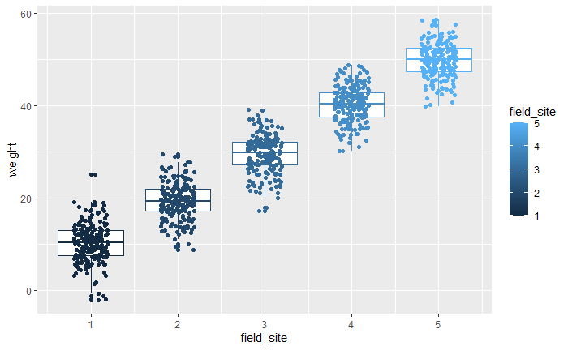

```r
#graph displaying the differences in weight between each field site
df_int %>% ggplot(mapping = aes(x = field_site, y = weight, colour = field_site, group = field_site)) +
  geom_boxplot() +
  geom_jitter(width = 0.2, height = 0)
```

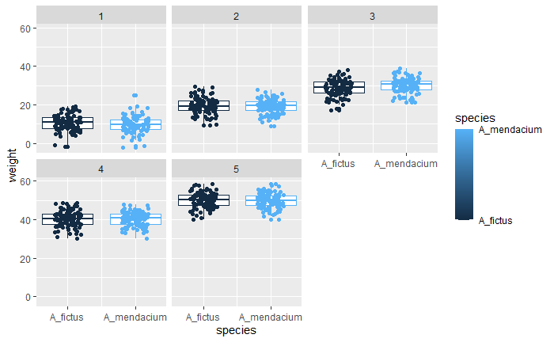

```r
df_int %>% ggplot(mapping = aes(x = species, y = weight, colour = species, group = species)) +
  geom_boxplot() +
  facet_wrap(~ field_site) +
  geom_jitter(width = 0.2, height = 0) +
  scale_x_continuous(breaks = seq(1,2, by=1), labels = species_names) +
  scale_colour_continuous(breaks = c(1,2), labels = species_names)
```

The signifant differences between the weight of both species over the five field sites is displayed over the two graphs. the second graph demonstrates the lack of significant difference in species weight within the field site, conveying the differences are in the field site alone.

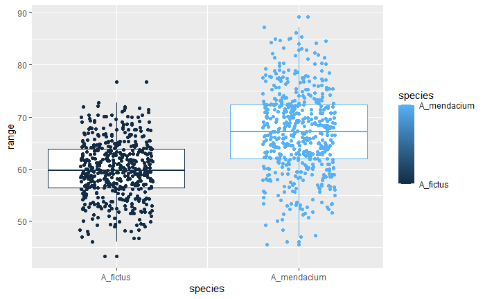

```r
#graphs displaying the differences in range between species and field sites in relation to each variable separately
df_int %>% ggplot(mapping = aes(x = species, y = range, colour = species, group = species)) +
  geom_boxplot() +
  geom_jitter(width = 0.2, height = 0) +
  scale_x_continuous(breaks = seq(1,2, by=1), labels = species_names) +
  scale_colour_continuous(breaks = c(1,2), labels = species_names)
```

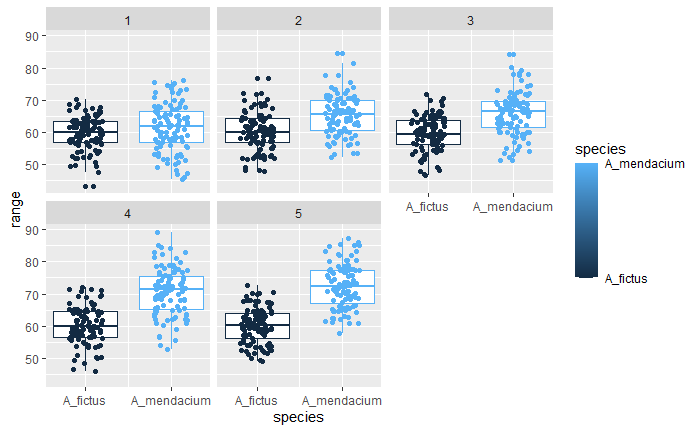

```r
df_int %>% ggplot(mapping = aes(x = species, y = range, colour = species, group = species)) +
  geom_boxplot() +
  facet_wrap(~ field_site) +
  geom_jitter(width = 0.2, height = 0) +
  scale_x_continuous(breaks = seq(1,2, by=1), labels = species_names) +
  scale_colour_continuous(breaks = c(1,2), labels = species_names)
```

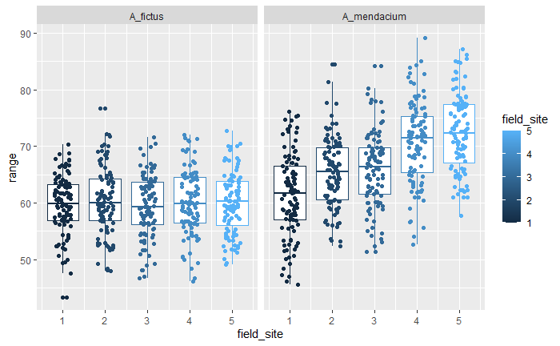

```r
species_labeller <- function(variable, value){
  return(species_names[value])
}

df_int %>% ggplot(mapping = aes(x = field_site, y = range, colour = field_site, group = field_site)) +
  geom_boxplot() +
  facet_grid(~ species, labeller = species_labeller) +
  geom_jitter(width = 0.2, height = 0)
```

The results convey the significant differences in range between the field sites for A mendacium, but not for A fictus. The three graphs demonstrate the overall differences in range over all five sites between the species, and comparing each field site’s differences in range.

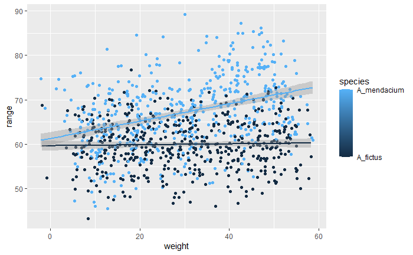

```r
#testing correlation between range and weight and species differences
df_int %>% ggplot(mapping = aes(x = weight, y = range, colour = species, group = species)) +
  geom_point() +
  geom_smooth(method=lm) +
  scale_colour_continuous(breaks = c(1,2), labels = species_names)
```

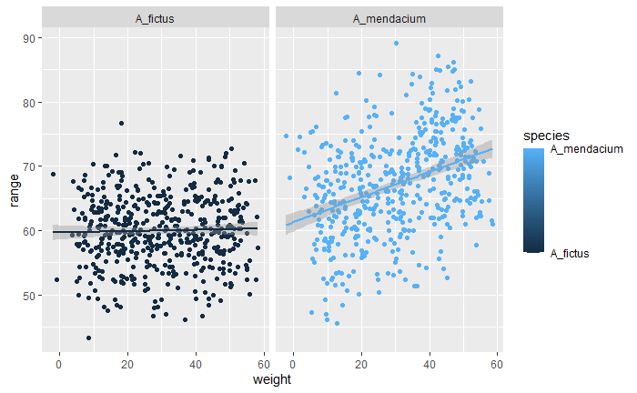

```r
df_int %>% ggplot(mapping = aes(x = weight, y = range, colour = species)) +
  geom_point() +
  geom_smooth(method=lm) +
  facet_grid(~ species, labeller = species_labeller) +
  scale_colour_continuous(breaks = c(1,2), labels = species_names)
```

Both graphs demonstrate some positive correlation between weight and range for A mendacium, as displayed by the line of best fit provided in the scatter graph, but no significant correlation for A fictus. Overall there is no significant correlation that could provide useful analysis in the study.

## Conclusion

The overall results of the study convey differences in weight of both species over the five field site. This could be due to increased resources between each field site, allowing for weight gain for the organisms feeding in the area, since the height of the species is consistent over the field sites so, the increase in weight cannot be due to increase in vertical size.

The results show an increase in range for the A mendacium species over the five field sites, but no difference in range for A fictus. Since the weight of each species increases in the same manner of weight increasing over the field sites, it could be concluded that the field sites have a increased amount of resources for each species, which either A mendacium’s resource pool is spread over a larger area requiring more roaming, or the species itself is more mobile than A fictus and the field sits with less resources have a higher density of resources that force A mendacium to remain in a smaller roaming area.